# P4_Travel_Package_Purchase

## Background and Context

You are a Data Scientist for a tourism company named "Visit with us". The Policy Maker of the company wants to enable and establish a viable business model to expand the customer base.

A viable business model is a central concept that helps you to understand the existing ways of doing the business and how to change the ways for the benefit of the tourism sector.

One of the ways to expand the customer base is to introduce a new offering of packages.

Currently, there are 5 types of packages the company is offering - Basic, Standard, Deluxe, Super Deluxe, King. Looking at the data of the last year, we observed that 18% of the customers purchased the packages.

However, the marketing cost was quite high because customers were contacted at random without looking at the available information.

The company is now planning to launch a new product i.e. Wellness Tourism Package. Wellness Tourism is defined as Travel that allows the traveler to maintain, enhance or kick-start a healthy lifestyle, and support or increase one's sense of well-being.

However, this time company wants to harness the available data of existing and potential customers to make the marketing expenditure more efficient.

You as a Data Scientist at "Visit with us" travel company have to analyze the customers' data and information to provide recommendations to the Policy Maker and Marketing Team and also build a model to predict the potential customer who is going to purchase the newly introduced travel package.

## Objective

To predict which customer is more likely to purchase the newly introduced travel package.

## Data Dictionary

Customer details:

CustomerID: Unique customer ID ProdTaken: Whether the customer has purchased a package or not (0: No, 1: Yes) Age: Age of customer TypeofContact: How customer was contacted (Company Invited or Self Inquiry) CityTier: City tier depends on the development of a city, population, facilities, and living standards. The categories are ordered i.e. Tier 1 > Tier 2 > Tier 3 Occupation: Occupation of customer Gender: Gender of customer NumberOfPersonVisiting: Total number of persons planning to take the trip with the customer PreferredPropertyStar: Preferred hotel property rating by customer MaritalStatus: Marital status of customer NumberOfTrips: Average number of trips in a year by customer Passport: The customer has a passport or not (0: No, 1: Yes) OwnCar: Whether the customers own a car or not (0: No, 1: Yes) NumberOfChildrenVisiting: Total number of children with age less than 5 planning to take the trip with the customer Designation: Designation of the customer in the current organization MonthlyIncome: Gross monthly income of the customer Customer interaction data:

PitchSatisfactionScore: Sales pitch satisfaction score ProductPitched: Product pitched by the salesperson NumberOfFollowups: Total number of follow-ups has been done by the salesperson after the sales pitch DurationOfPitch: Duration of the pitch by a salesperson to the customer

Perform an Exploratory Data Analysis on the data

- Univariate analysis - Bivariate analysis - Use appropriate visualizations to identify the patterns and insights - Come up with a customer profile (characteristics of a customer) of the different packages - Any other exploratory deep dive 8

Illustrate the insights based on EDA Key meaningful observations on individual variables and the relationship between variables 4

Data Pre-processing Prepare the data for analysis - Missing value Treatment, Outlier Detection (treat, if needed- why or why not ), Feature Engineering, Prepare data for modeling 7

Model building - Bagging

- Build bagging classifier, random forest, and decision tree. 4

Model performance improvement - Bagging

- Comment on which metric is right for model performance evaluation and why? - Comment on model performance - Can model performance be improved? check and comment 9

Model building - Boosting

- Build Adaboost, gradient boost, xgboost, and stacking classifier 6

Model performance improvement - Boosting

- Comment on which metric is right for model performance evaluation and why? - Comment on model performance - Can model performance be improved? check and comment 9

Model performance evaluation Evaluate the model on different performance metrics and comment on the performance and scope of improvement 4

Actionable Insights & Recommendations

- Conclude with the key takeaways for the business - What would your advice be to grow the business? 5

Notebook - Overall

- Structure and flow - Well commented code 4

## Index

- Overview of the dataset
- Exploratory Data Analysis
- Data Preprocessing
- Split the dataset
- Bagging Models
- Decision Tree Model
- Random Forest Model
- Bagging Classifier
- Boosting Models
- Stacking Classifier
- Comparing all Models
- Business Recommendations

```python
import numpy as np
import pandas as pd
import matplotlib.pyplot as plt
import seaborn as sns
from sklearn.tree import DecisionTreeClassifier
from sklearn.ensemble import BaggingClassifier
from sklearn.ensemble import RandomForestClassifier
from sklearn.ensemble import AdaBoostClassifier, GradientBoostingClassifier
from xgboost import XGBClassifier
from sklearn.ensemble import StackingClassifier
from sklearn.tree import DecisionTreeClassifier
from sklearn.ensemble import AdaBoostClassifier, GradientBoostingClassifier
from sklearn.model_selection import train_test_split
from sklearn.metrics import confusion_matrix, classification_report
from sklearn.metrics import accuracy_score,precision_score,recall_score,f1_score
import scipy.stats as stats
from sklearn import metrics
from sklearn import tree
from sklearn.model_selection import GridSearchCV, RandomizedSearchCV
from sklearn.ensemble import BaggingClassifier
from sklearn.ensemble import RandomForestClassifier
import xgboost as xgb
from xgboost import XGBRegressor
import warnings
warnings.filterwarnings('ignore')
```

## Overview of the dataset

```python
df = pd.read_excel('Tourism.xlsx', sheet_name="Tourism",engine='openpyxl')
```

```python
df.sample(10)
```

|  | CustomerID | ProdTaken | Age | TypeofContact | CityTier | DurationOfPitch | Occupation | Gender | NumberOfPersonVisiting | NumberOfFollowups | ProductPitched | PreferredPropertyStar | MaritalStatus | NumberOfTrips | Passport | PitchSatisfactionScore | OwnCar | NumberOfChildrenVisiting | Designation | MonthlyIncome |
| --- | --- | --- | --- | --- | --- | --- | --- | --- | --- | --- | --- | --- | --- | --- | --- | --- | --- | --- | --- | --- |
| 3616 | 203616 | 0 | 30.0 | Self Enquiry | 3 | 17.0 | Small Business | Male | 3 | 5.0 | Deluxe | 3.0 | Unmarried | 2.0 | 0 | 4 | 1 | 1.0 | Manager | 24547.0 |
| 3249 | 203249 | 0 | 46.0 | Company Invited | 3 | 16.0 | Salaried | Female | 4 | 5.0 | Deluxe | 3.0 | Divorced | 3.0 | 0 | 3 | 0 | 1.0 | Manager | 24271.0 |
| 4780 | 204780 | 0 | 41.0 | Company Invited | 3 | 9.0 | Small Business | Male | 4 | 4.0 | Deluxe | 4.0 | Married | 7.0 | 0 | 4 | 1 | 2.0 | Manager | 23005.0 |
| 704 | 200704 | 0 | 35.0 | Self Enquiry | 3 | 9.0 | Salaried | Male | 3 | 3.0 | Standard | 3.0 | Married | 7.0 | 0 | 5 | 0 | 1.0 | Senior Manager | 22823.0 |
| 2184 | 202184 | 0 | 50.0 | Self Enquiry | 1 | 6.0 | Small Business | Male | 3 | 3.0 | Super Deluxe | 3.0 | Married | 1.0 | 0 | 5 | 0 | 2.0 | AVP | 32399.0 |
| 3619 | 203619 | 0 | 40.0 | Self Enquiry | 1 | 19.0 | Small Business | Male | 4 | 4.0 | Deluxe | 4.0 | Married | 6.0 | 0 | 3 | 1 | 2.0 | Manager | 23973.0 |
| 1723 | 201723 | 0 | 42.0 | Self Enquiry | 1 | 23.0 | Salaried | Female | 2 | 1.0 | Deluxe | 5.0 | Unmarried | 4.0 | 1 | 1 | 1 | 1.0 | Manager | 21545.0 |
| 4823 | 204823 | 1 | 20.0 | Self Enquiry | 3 | 12.0 | Salaried | Male | 4 | 4.0 | Standard | 4.0 | Unmarried | 2.0 | 1 | 4 | 1 | 1.0 | Senior Manager | 21672.0 |
| 824 | 200824 | 0 | 42.0 | Self Enquiry | 1 | NaN | Small Business | Male | 2 | 5.0 | Deluxe | 3.0 | Single | 5.0 | 0 | 3 | 1 | 0.0 | Manager | NaN |
| 3838 | 203838 | 0 | 33.0 | Self Enquiry | 1 | 12.0 | Salaried | Male | 3 | 5.0 | Deluxe | 3.0 | Unmarried | 2.0 | 0 | 1 | 0 | 2.0 | Manager | 28357.0 |

```python
df.shape
```

```
(4888, 20)
```

```python
df.info()
```

```
<class 'pandas.core.frame.DataFrame'>
RangeIndex: 4888 entries, 0 to 4887
Data columns (total 20 columns):
 #   Column                    Non-Null Count  Dtype
---  ------                    --------------  -----
 0   CustomerID                4888 non-null   int64
 1   ProdTaken                 4888 non-null   int64
 2   Age                       4662 non-null   float64
 3   TypeofContact             4863 non-null   object
 4   CityTier                  4888 non-null   int64
 5   DurationOfPitch           4637 non-null   float64
 6   Occupation                4888 non-null   object
 7   Gender                    4888 non-null   object
 8   NumberOfPersonVisiting    4888 non-null   int64
 9   NumberOfFollowups         4843 non-null   float64
 10  ProductPitched            4888 non-null   object
 11  PreferredPropertyStar     4862 non-null   float64
 12  MaritalStatus             4888 non-null   object
 13  NumberOfTrips             4748 non-null   float64
 14  Passport                  4888 non-null   int64
 15  PitchSatisfactionScore    4888 non-null   int64
 16  OwnCar                    4888 non-null   int64
 17  NumberOfChildrenVisiting  4822 non-null   float64
 18  Designation               4888 non-null   object
 19  MonthlyIncome             4655 non-null   float64
dtypes: float64(7), int64(7), object(6)
memory usage: 763.9+ KB
```

```python
for feature in df.columns: # Loop through all columns in the dataframe
    if df[feature].dtype == 'object': # Only apply for columns with categorical strings
        df[feature] = pd.Categorical(df[feature])# Replace strings with an integer
df.head(10)
```

|  | CustomerID | ProdTaken | Age | TypeofContact | CityTier | DurationOfPitch | Occupation | Gender | NumberOfPersonVisiting | NumberOfFollowups | ProductPitched | PreferredPropertyStar | MaritalStatus | NumberOfTrips | Passport | PitchSatisfactionScore | OwnCar | NumberOfChildrenVisiting | Designation | MonthlyIncome |
| --- | --- | --- | --- | --- | --- | --- | --- | --- | --- | --- | --- | --- | --- | --- | --- | --- | --- | --- | --- | --- |
| 0 | 200000 | 1 | 41.0 | Self Enquiry | 3 | 6.0 | Salaried | Female | 3 | 3.0 | Deluxe | 3.0 | Single | 1.0 | 1 | 2 | 1 | 0.0 | Manager | 20993.0 |
| 1 | 200001 | 0 | 49.0 | Company Invited | 1 | 14.0 | Salaried | Male | 3 | 4.0 | Deluxe | 4.0 | Divorced | 2.0 | 0 | 3 | 1 | 2.0 | Manager | 20130.0 |
| 2 | 200002 | 1 | 37.0 | Self Enquiry | 1 | 8.0 | Free Lancer | Male | 3 | 4.0 | Basic | 3.0 | Single | 7.0 | 1 | 3 | 0 | 0.0 | Executive | 17090.0 |
| 3 | 200003 | 0 | 33.0 | Company Invited | 1 | 9.0 | Salaried | Female | 2 | 3.0 | Basic | 3.0 | Divorced | 2.0 | 1 | 5 | 1 | 1.0 | Executive | 17909.0 |
| 4 | 200004 | 0 | NaN | Self Enquiry | 1 | 8.0 | Small Business | Male | 2 | 3.0 | Basic | 4.0 | Divorced | 1.0 | 0 | 5 | 1 | 0.0 | Executive | 18468.0 |
| 5 | 200005 | 0 | 32.0 | Company Invited | 1 | 8.0 | Salaried | Male | 3 | 3.0 | Basic | 3.0 | Single | 1.0 | 0 | 5 | 1 | 1.0 | Executive | 18068.0 |
| 6 | 200006 | 0 | 59.0 | Self Enquiry | 1 | 9.0 | Small Business | Female | 2 | 2.0 | Basic | 5.0 | Divorced | 5.0 | 1 | 2 | 1 | 1.0 | Executive | 17670.0 |
| 7 | 200007 | 0 | 30.0 | Self Enquiry | 1 | 30.0 | Salaried | Male | 3 | 3.0 | Basic | 3.0 | Married | 2.0 | 0 | 2 | 0 | 1.0 | Executive | 17693.0 |
| 8 | 200008 | 0 | 38.0 | Company Invited | 1 | 29.0 | Salaried | Male | 2 | 4.0 | Standard | 3.0 | Unmarried | 1.0 | 0 | 3 | 0 | 0.0 | Senior Manager | 24526.0 |
| 9 | 200009 | 0 | 36.0 | Self Enquiry | 1 | 33.0 | Small Business | Male | 3 | 3.0 | Deluxe | 3.0 | Divorced | 7.0 | 0 | 3 | 1 | 0.0 | Manager | 20237.0 |

```python
df.info()
```

```
<class 'pandas.core.frame.DataFrame'>
RangeIndex: 4888 entries, 0 to 4887
Data columns (total 20 columns):
 #   Column                    Non-Null Count  Dtype
---  ------                    --------------  -----
 0   CustomerID                4888 non-null   int64
 1   ProdTaken                 4888 non-null   int64
 2   Age                       4662 non-null   float64
 3   TypeofContact             4863 non-null   category
 4   CityTier                  4888 non-null   int64
 5   DurationOfPitch           4637 non-null   float64
 6   Occupation                4888 non-null   category
 7   Gender                    4888 non-null   category
 8   NumberOfPersonVisiting    4888 non-null   int64
 9   NumberOfFollowups         4843 non-null   float64
 10  ProductPitched            4888 non-null   category
 11  PreferredPropertyStar     4862 non-null   float64
 12  MaritalStatus             4888 non-null   category
 13  NumberOfTrips             4748 non-null   float64
 14  Passport                  4888 non-null   int64
 15  PitchSatisfactionScore    4888 non-null   int64
 16  OwnCar                    4888 non-null   int64
 17  NumberOfChildrenVisiting  4822 non-null   float64
 18  Designation               4888 non-null   category
 19  MonthlyIncome             4655 non-null   float64
dtypes: category(6), float64(7), int64(7)
memory usage: 564.4 KB
```

```python
df.describe().T
```

|  | count | mean | std | min | 25% | 50% | 75% | max |
| --- | --- | --- | --- | --- | --- | --- | --- | --- |
| CustomerID | 4888.0 | 202443.500000 | 1411.188388 | 200000.0 | 201221.75 | 202443.5 | 203665.25 | 204887.0 |
| ProdTaken | 4888.0 | 0.188216 | 0.390925 | 0.0 | 0.00 | 0.0 | 0.00 | 1.0 |
| Age | 4662.0 | 37.622265 | 9.316387 | 18.0 | 31.00 | 36.0 | 44.00 | 61.0 |
| CityTier | 4888.0 | 1.654255 | 0.916583 | 1.0 | 1.00 | 1.0 | 3.00 | 3.0 |
| DurationOfPitch | 4637.0 | 15.490835 | 8.519643 | 5.0 | 9.00 | 13.0 | 20.00 | 127.0 |
| NumberOfPersonVisiting | 4888.0 | 2.905074 | 0.724891 | 1.0 | 2.00 | 3.0 | 3.00 | 5.0 |
| NumberOfFollowups | 4843.0 | 3.708445 | 1.002509 | 1.0 | 3.00 | 4.0 | 4.00 | 6.0 |
| PreferredPropertyStar | 4862.0 | 3.581037 | 0.798009 | 3.0 | 3.00 | 3.0 | 4.00 | 5.0 |
| NumberOfTrips | 4748.0 | 3.236521 | 1.849019 | 1.0 | 2.00 | 3.0 | 4.00 | 22.0 |
| Passport | 4888.0 | 0.290917 | 0.454232 | 0.0 | 0.00 | 0.0 | 1.00 | 1.0 |
| PitchSatisfactionScore | 4888.0 | 3.078151 | 1.365792 | 1.0 | 2.00 | 3.0 | 4.00 | 5.0 |
| OwnCar | 4888.0 | 0.620295 | 0.485363 | 0.0 | 0.00 | 1.0 | 1.00 | 1.0 |
| NumberOfChildrenVisiting | 4822.0 | 1.187267 | 0.857861 | 0.0 | 1.00 | 1.0 | 2.00 | 3.0 |
| MonthlyIncome | 4655.0 | 23619.853491 | 5380.698361 | 1000.0 | 20346.00 | 22347.0 | 25571.00 | 98678.0 |

```python
df.nunique()
```

```
CustomerID                  4888
ProdTaken                      2
Age                           44
TypeofContact                  2
CityTier                       3
DurationOfPitch               34
Occupation                     4
Gender                         3
NumberOfPersonVisiting         5
NumberOfFollowups              6
ProductPitched                 5
PreferredPropertyStar          3
MaritalStatus                  4
NumberOfTrips                 12
Passport                       2
PitchSatisfactionScore         5
OwnCar                         2
NumberOfChildrenVisiting       4
Designation                    5
MonthlyIncome               2475
dtype: int64
```

```python
df.isna().sum().sort_values(ascending = False)
```

```
DurationOfPitch             251
MonthlyIncome               233
Age                         226
NumberOfTrips               140
NumberOfChildrenVisiting     66
NumberOfFollowups            45
PreferredPropertyStar        26
TypeofContact                25
Passport                      0
MaritalStatus                 0
ProductPitched                0
Designation                   0
NumberOfPersonVisiting        0
Gender                        0
Occupation                    0
PitchSatisfactionScore        0
CityTier                      0
OwnCar                        0
ProdTaken                     0
CustomerID                    0
dtype: int64
```

## EDA

### Univariate analysis

```python
# While doing uni-variate analysis of numerical variables we want to study their central tendency
# and dispersion.
# Let us write a function that will help us create boxplot and histogram for any input numerical
# variable.
# This function takes the numerical column as the input and returns the boxplots
# and histograms for the variable.
# Let us see if this help us write faster and cleaner code.
def histogram_boxplot(feature, figsize=(15,10), bins = None):
    """ Boxplot and histogram combined
    feature: 1-d feature array
    figsize: size of fig (default (9,8))
    bins: number of bins (default None / auto)
    """
    f2, (ax_box2, ax_hist2) = plt.subplots(nrows = 2, # Number of rows of the subplot grid= 2
                                           sharex = True, # x-axis will be shared among all subplots
                                           gridspec_kw = {"height_ratios": (.25, .75)},
                                           figsize = figsize
                                           ) # creating the 2 subplots
    sns.boxplot(feature, ax=ax_box2, showmeans=True, color='violet') # boxplot will be created and a star will indicate the mean value of the column
    sns.distplot(feature, kde=F, ax=ax_hist2, bins=bins,palette="winter") if bins else sns.distplot(feature, kde=False, ax=ax_hist2) # For histogram
    ax_hist2.axvline(np.mean(feature), color='green', linestyle='--') # Add mean to the histogram
    ax_hist2.axvline(np.median(feature), color='black', linestyle='-') # Add median to the histogram
```

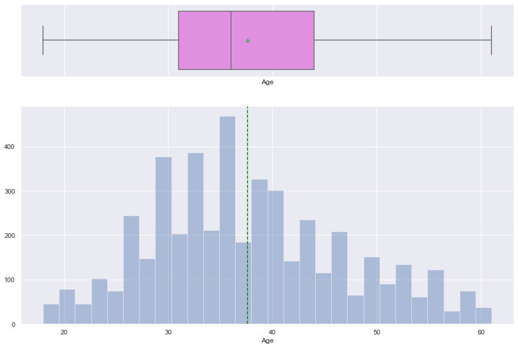

```python
histogram_boxplot(df['Age'])
```

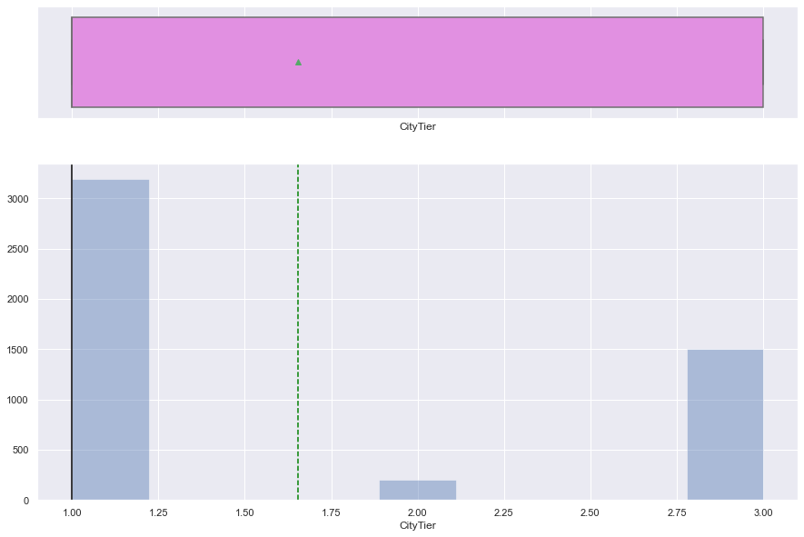

```python
histogram_boxplot(df['CityTier'])
```

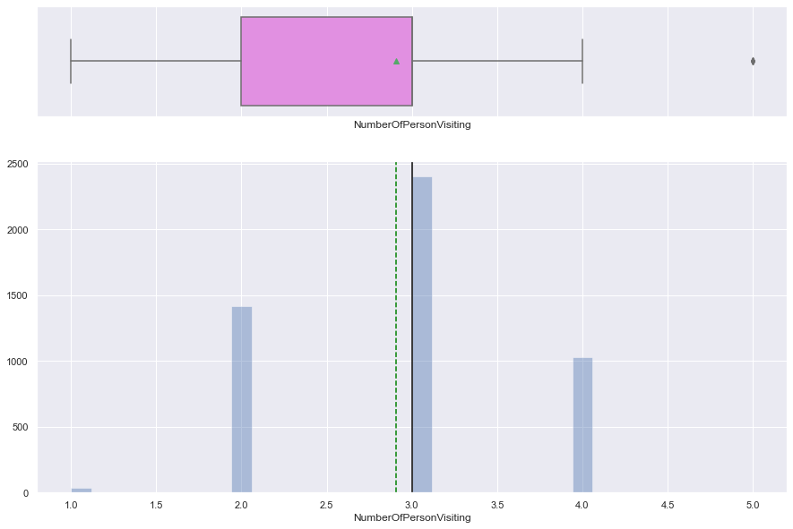

```python
histogram_boxplot(df['NumberOfPersonVisiting'])
```

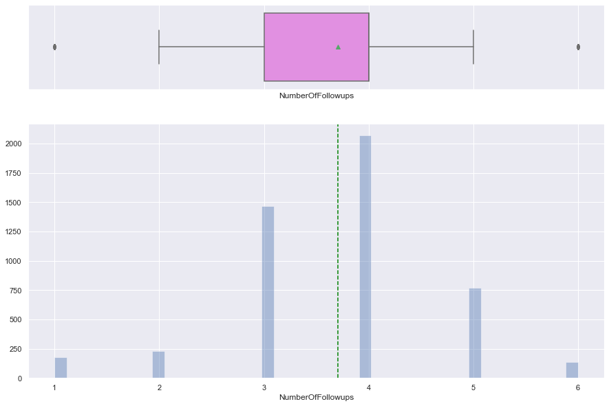

```python
histogram_boxplot(df['NumberOfFollowups'])
```

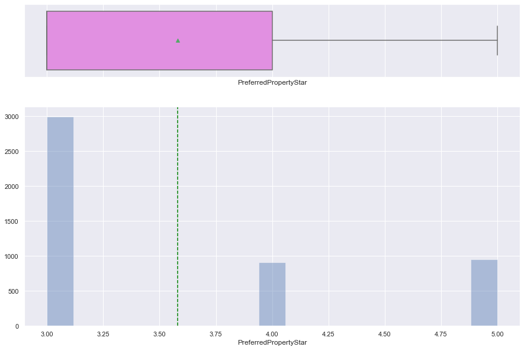

```python
histogram_boxplot(df['PreferredPropertyStar'])
```

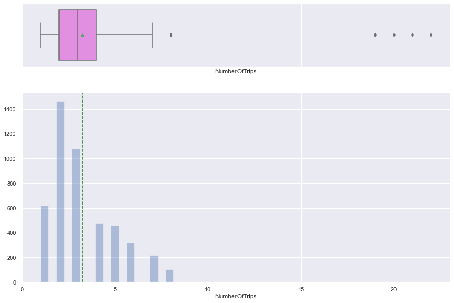

```python
histogram_boxplot(df['NumberOfTrips'])
```

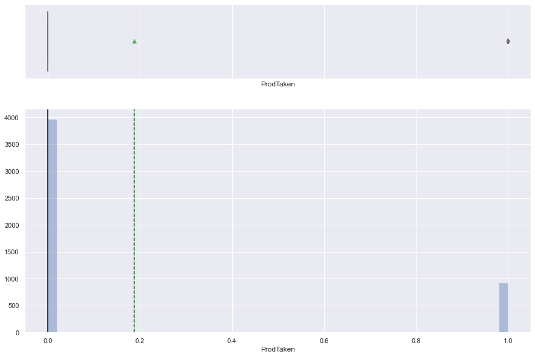

```python
histogram_boxplot(df['ProdTaken'])
```

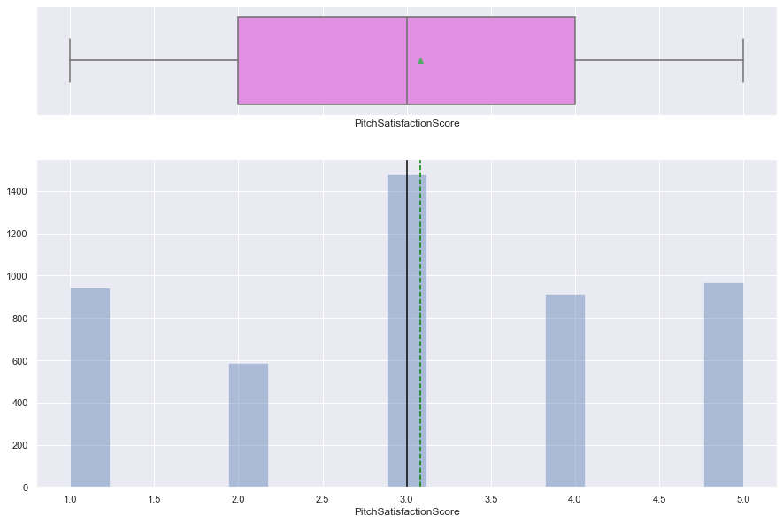

```python
histogram_boxplot(df['PitchSatisfactionScore'])
```

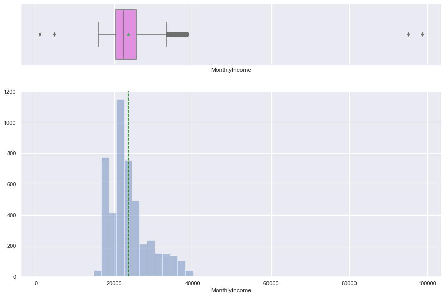

```python
histogram_boxplot(df['MonthlyIncome'])
```

### Bivariate analysis

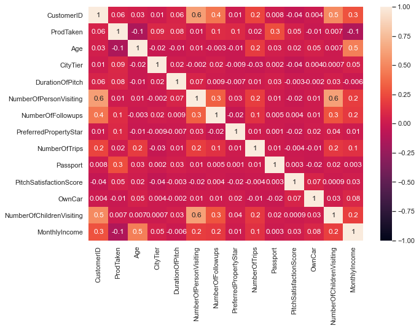

```python
plt.figure(figsize=(10,7))
sns.heatmap(df.corr(),annot=True,vmin=-1,vmax=1,fmt='.1g')
plt.show()
```

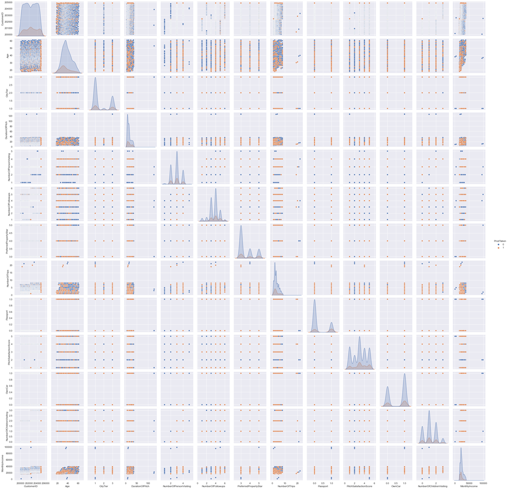

```python
sns.pairplot(df,hue='ProdTaken')
plt.show()
```

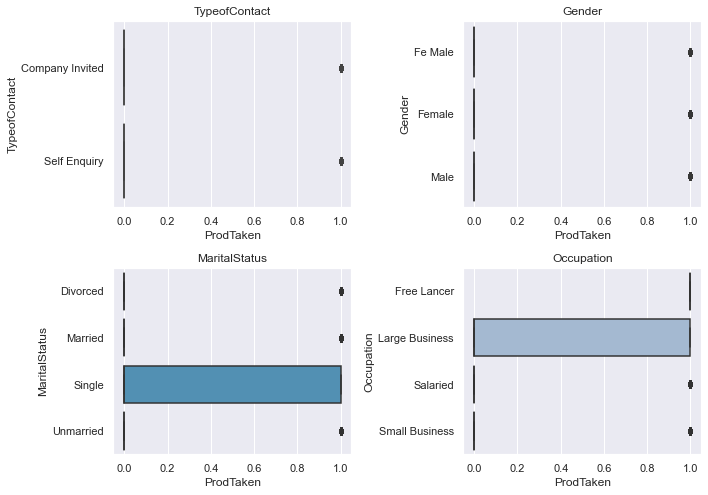

```python
cols = df[['TypeofContact','Gender','MaritalStatus','Occupation']].columns.tolist()
plt.figure(figsize=(10,10))

for i, variable in enumerate(cols):
                     plt.subplot(3,2,i+1)
                     sns.boxplot(df["ProdTaken"],df[variable],palette="PuBu")
                     plt.tight_layout()
                     plt.title(variable)
plt.show()
```

```python
### Function to plot stacked bar charts for categorical columns
def stacked_plot(x):
    sns.set(palette='nipy_spectral')
    tab1 = pd.crosstab(x,df['ProdTaken'],margins=True)
    print(tab1)
    print('-'*120)
    tab = pd.crosstab(x,df['ProdTaken'],normalize='index')
    tab.plot(kind='bar',stacked=True,figsize=(10,5))
    plt.legend(loc='lower left', frameon=False)
    plt.legend(loc="upper left", bbox_to_anchor=(1,1))
    plt.show()
```

```
ProdTaken          0    1   All
Occupation
Free Lancer        0    2     2
Large Business   314  120   434
Salaried        1954  414  2368
Small Business  1700  384  2084
All             3968  920  4888
------------------------------------------------------------------------------------------------------------------------
```

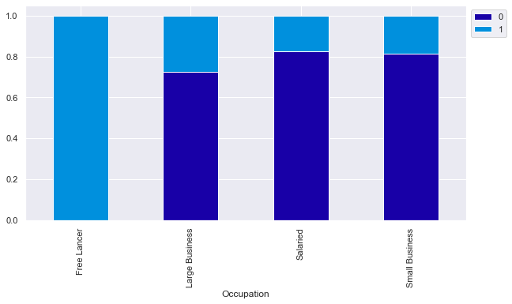

```python
stacked_plot(df['Occupation'])
```

```
ProdTaken           0    1   All
TypeofContact
Company Invited  1109  310  1419
Self Enquiry     2837  607  3444
All              3946  917  4863
------------------------------------------------------------------------------------------------------------------------
```

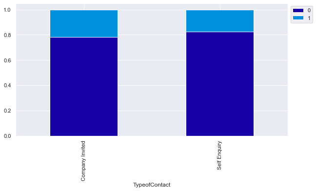

```python
stacked_plot(df['TypeofContact'])
```

```
ProdTaken     0    1   All
Gender
Fe Male     130   25   155
Female     1500  317  1817
Male       2338  578  2916
All        3968  920  4888
------------------------------------------------------------------------------------------------------------------------
```

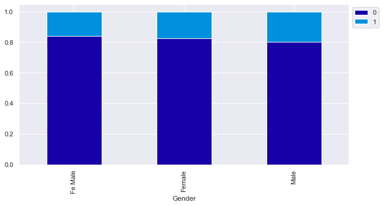

```python
stacked_plot(df['Gender'])
```

```
ProdTaken         0    1   All
MaritalStatus
Divorced        826  124   950
Married        2014  326  2340
Single          612  304   916
Unmarried       516  166   682
All            3968  920  4888
------------------------------------------------------------------------------------------------------------------------
```

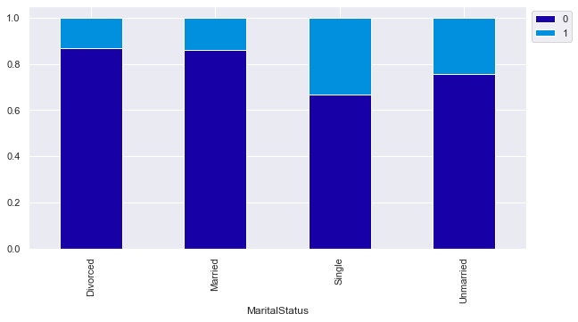

```python
stacked_plot(df['MaritalStatus'])
```

```
ProdTaken          0    1   All
ProductPitched
Basic           1290  552  1842
Deluxe          1528  204  1732
King             210   20   230
Standard         618  124   742
Super Deluxe     322   20   342
All             3968  920  4888
------------------------------------------------------------------------------------------------------------------------
```

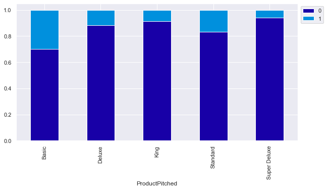

```python
stacked_plot(df['ProductPitched'])
```

```
ProdTaken                 0    1   All
PreferredPropertyStar
3.0                    2511  482  2993
4.0                     731  182   913
5.0                     706  250   956
All                    3948  914  4862
------------------------------------------------------------------------------------------------------------------------
```

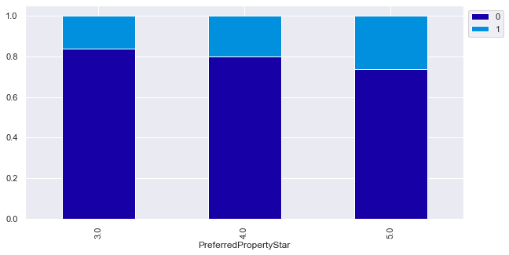

```python
stacked_plot(df['PreferredPropertyStar'])
```

```
ProdTaken          0    1   All
Designation
AVP              322   20   342
Executive       1290  552  1842
Manager         1528  204  1732
Senior Manager   618  124   742
VP               210   20   230
All             3968  920  4888
------------------------------------------------------------------------------------------------------------------------
```

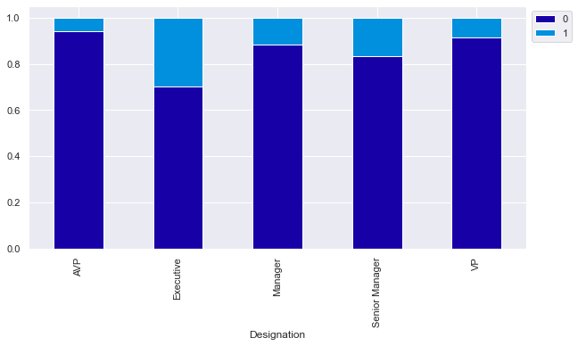

```python
stacked_plot(df['Designation'])
```

## Data Preprocessing

```python
#Dummy Variables
df_dummies = pd.get_dummies(df, prefix=None, prefix_sep='_',dummy_na=False, columns=None, sparse=False, drop_first=False, dtype=None)
```

```python
#drop infinity and missing values
df_dummies = df_dummies.dropna(how='any')
```

## Split the dataset

```python
# Separating features and the target column
X = df_dummies.drop('ProdTaken', axis=1)
y = df_dummies['ProdTaken']
```

```python
# Splitting the data into train and test sets in 70:30 ratio
X_train, X_test, y_train, y_test = train_test_split(X, y, test_size=0.30, random_state=1, shuffle=True)
```

```python
X_train.shape, X_test.shape
```

```
((2889, 36), (1239, 36))
```

```python
y.value_counts(1)
```

```
0    0.806928
1    0.193072
Name: ProdTaken, dtype: float64
```

```python
y_test.value_counts(1)
```

```
0    0.799031
1    0.200969
Name: ProdTaken, dtype: float64
```

```python
##  Function to calculate different metric scores of the model - Accuracy, Recall and Precision
def get_metrics_score(model,flag=True):
    '''
    model : classifier to predict values of X

    '''
    # defining an empty list to store train and test results
    score_list=[]

    pred_train = model.predict(X_train)
    pred_test = model.predict(X_test)

    train_acc = model.score(X_train,y_train)
    test_acc = model.score(X_test,y_test)

    train_recall = metrics.recall_score(y_train,pred_train)
    test_recall = metrics.recall_score(y_test,pred_test)

    train_precision = metrics.precision_score(y_train,pred_train)
    test_precision = metrics.precision_score(y_test,pred_test)

    train_f1 = f1_score(y_train,pred_train)
    test_f1 = f1_score(y_test,pred_test)

    score_list.extend((train_acc,test_acc,train_recall,test_recall,train_precision,test_precision, train_f1, test_f1))

    # If the flag is set to True then only the following print statements will be dispayed. The default value is set to True.
    if flag == True:
        print("Accuracy on training set : ",model.score(X_train,y_train))
        print("Accuracy on test set : ",model.score(X_test,y_test))
        print("Recall on training set : ",metrics.recall_score(y_train,pred_train))
        print("Recall on test set : ",metrics.recall_score(y_test,pred_test))
        print("Precision on training set : ",metrics.precision_score(y_train,pred_train))
        print("Precision on test set : ",metrics.precision_score(y_test,pred_test))
        print("F1-Score on training set : ",metrics.f1_score(y_train,pred_train))
        print("F1-Score on test set : ",metrics.f1_score(y_test,pred_test))

    return score_list # returning the list with train and test scores
```

```python
## Function to create confusion matrix
def make_confusion_matrix(model,y_actual,labels=[1, 0]):
    '''
    model : classifier to predict values of X
    y_actual : ground truth

    '''
    y_predict = model.predict(X_test)
    cm=metrics.confusion_matrix( y_actual, y_predict, labels=[0, 1])
    df_cm = pd.DataFrame(cm, index = [i for i in ["Actual - No","Actual - Yes"]],
                  columns = [i for i in ['Predicted - No','Predicted - Yes']])
    group_counts = ["{0:0.0f}".format(value) for value in
                cm.flatten()]
    group_percentages = ["{0:.2%}".format(value) for value in
                         cm.flatten()/np.sum(cm)]
    labels = [f"{v1}\n{v2}" for v1, v2 in
              zip(group_counts,group_percentages)]
    labels = np.asarray(labels).reshape(2,2)
    plt.figure(figsize = (10,7))
    sns.heatmap(df_cm, annot=labels,fmt='')
    plt.ylabel('True label')
    plt.xlabel('Predicted label')
```

## Decision Tree Model

```python
#Fitting the model
d_tree = DecisionTreeClassifier(random_state=1)
d_tree.fit(X_train,y_train)

#Calculating different metrics
get_metrics_score(d_tree);
```

```
Accuracy on training set :  1.0
Accuracy on test set :  0.8757062146892656
Recall on training set :  1.0
Recall on test set :  0.7108433734939759
Precision on training set :  1.0
Precision on test set :  0.6833976833976834
F1-Score on training set :  1.0
F1-Score on test set :  0.6968503937007874
```

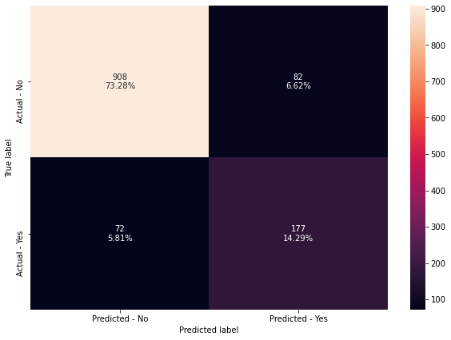

```python
#Creating confusion matrix
make_confusion_matrix(d_tree,y_test)
```

#### interpretation:

- There is overfitting in all aspects on the training set
- The recall & F1-score on the test set is meagre

### Hyperparameter Tuning (decision tree)

```python
#Choose the type of classifier.
dtree_estimator = DecisionTreeClassifier(class_weight={0:0.18,1:0.72},random_state=1)

# Grid of parameters to choose from
parameters = {'max_depth': np.arange(2,30),
              'min_samples_leaf': [1, 2, 5, 7, 10],
              'max_leaf_nodes' : [2, 3, 5, 10,15],
              'min_impurity_decrease': [0.0001,0.001,0.01,0.1]
             }

# Type of scoring used to compare parameter combinations
scorer = metrics.make_scorer(metrics.f1_score)

# Run the grid search
grid_obj = RandomizedSearchCV(dtree_estimator, parameters, scoring=scorer,n_jobs=-1)
grid_obj = grid_obj.fit(X_train, y_train)

# Set the clf to the best combination of parameters
dtree_estimator = grid_obj.best_estimator_

# Fit the best algorithm to the data.
dtree_estimator.fit(X_train, y_train)
```

```
DecisionTreeClassifier(class_weight={0: 0.18, 1: 0.72}, max_depth=5,
                       max_leaf_nodes=10, min_impurity_decrease=0.001,
                       min_samples_leaf=5, random_state=1)
```

```python
get_metrics_score(dtree_estimator);
```

```
Accuracy on training set :  0.8231221876081689
Accuracy on test set :  0.8216303470540759
Recall on training set :  0.6295620437956204
Recall on test set :  0.5903614457831325
Precision on training set :  0.5283307810107197
Precision on test set :  0.5526315789473685
F1-Score on training set :  0.5745212323064114
F1-Score on test set :  0.5708737864077671
```

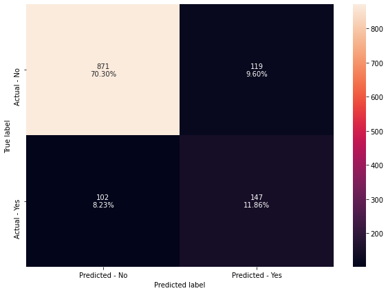

```python
make_confusion_matrix(dtree_estimator,y_test)
```

#### interpretation:

- less overfitting now, but less accurate too
- the recall and F1-score are not ideal at all
- hypertuning is not yielding a much better result

## Random Forest Model

```python
#Fitting the model
rf_estimator = RandomForestClassifier(random_state=1)
rf_estimator.fit(X_train,y_train)

#Calculating different metrics
get_metrics_score(rf_estimator);
```

```
Accuracy on training set :  1.0
Accuracy on test set :  0.9023405972558515
Recall on training set :  1.0
Recall on test set :  0.5421686746987951
Precision on training set :  1.0
Precision on test set :  0.9507042253521126
F1-Score on training set :  1.0
F1-Score on test set :  0.6905370843989769
```

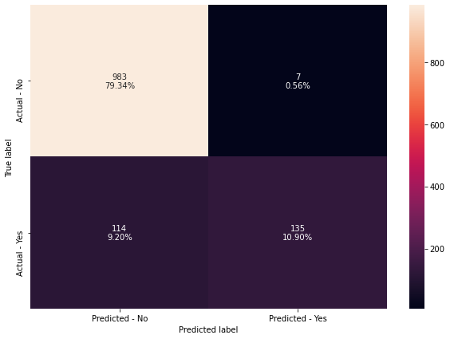

```python
#Creating confusion matrix
make_confusion_matrix(rf_estimator,y_test)
```

#### interpretation:

- recall is extremely bad, much missed opportunity on people who could have purchased the package
- precision is very high, which suggests overfitting

### Hyperparameter Tuning (random forest)

```python
# Choose the type of classifier.
rf_tuned = RandomForestClassifier(class_weight={0:0.18,1:0.82},random_state=1,oob_score=True,bootstrap=True)

parameters = {
                'max_depth': list(np.arange(5,30,5)) + [None],
                'max_features': ['sqrt','log2',None],
                'min_samples_leaf': np.arange(1,15,5),
                'min_samples_split': np.arange(2, 20, 5),
                'n_estimators': np.arange(10,110,10)}


# Type of scoring used to compare parameter combinations
scorer = metrics.make_scorer(metrics.f1_score)

# Run the grid search
grid_obj = RandomizedSearchCV(rf_tuned, parameters, scoring=scorer, cv=5,n_jobs=-1)
grid_obj = grid_obj.fit(X_train, y_train)

# Set the clf to the best combination of parameters
rf_tuned = grid_obj.best_estimator_

# Fit the best algorithm to the data.
rf_tuned.fit(X_train, y_train)
```

```
RandomForestClassifier(class_weight={0: 0.18, 1: 0.82}, max_depth=10,
                       max_features=None, min_samples_split=12, n_estimators=80,
                       oob_score=True, random_state=1)
```

```python
#Calculating different metrics
get_metrics_score(rf_tuned);
```

```
Accuracy on training set :  0.9598476981654551
Accuracy on test set :  0.8821630347054076
Recall on training set :  0.9562043795620438
Recall on test set :  0.6546184738955824
Precision on training set :  0.8506493506493507
Precision on test set :  0.7309417040358744
F1-Score on training set :  0.9003436426116839
F1-Score on test set :  0.6906779661016949
```

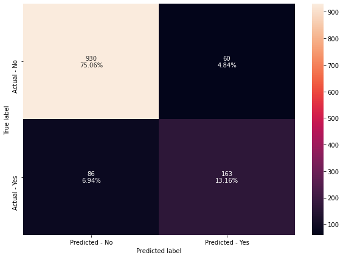

```python
#Creating confusion matrix
make_confusion_matrix(rf_tuned,y_test)
```

## Bagging Classifier

```python
#Fitting the model
bagging_classifier = BaggingClassifier(random_state=1)
bagging_classifier.fit(X_train,y_train)

#Calculating different metrics
get_metrics_score(bagging_classifier);
```

```
Accuracy on training set :  0.9916926272066459
Accuracy on test set :  0.8999192897497982
Recall on training set :  0.9598540145985401
Recall on test set :  0.5662650602409639
Precision on training set :  0.9962121212121212
Precision on test set :  0.8980891719745223
F1-Score on training set :  0.9776951672862454
F1-Score on test set :  0.6945812807881775
```

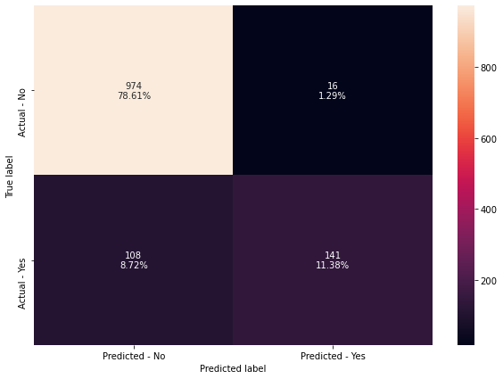

```python
#Creating confusion matrix
make_confusion_matrix(bagging_classifier,y_test)
```

### Hyperparameter Tuning

```python
# Choose the type of classifier.
bagging_estimator_tuned = BaggingClassifier(random_state=1)

# Grid of parameters to choose from
parameters = {'max_samples': [0.7,0.8,0.9,1],
              'max_features': [0.7,0.8,0.9,1],
              'n_estimators' : [10,20,30,40,50],
             }

# Type of scoring used to compare parameter combinations
scorer = metrics.make_scorer(metrics.f1_score)

# Run the grid search
grid_obj = RandomizedSearchCV(bagging_estimator_tuned, parameters, scoring=scorer,cv=5)
grid_obj = grid_obj.fit(X_train, y_train)

# Set the clf to the best combination of parameters
bagging_estimator_tuned = grid_obj.best_estimator_

# Fit the best algorithm to the data.
bagging_estimator_tuned.fit(X_train, y_train)
```

```
BaggingClassifier(max_features=0.9, max_samples=0.9, n_estimators=30,
                  random_state=1)
```

```python
#Calculating different metrics
get_metrics_score(bagging_estimator_tuned);
```

```
Accuracy on training set :  0.9986154378677743
Accuracy on test set :  0.8918482647296206
Recall on training set :  0.9927007299270073
Recall on test set :  0.5100401606425703
Precision on training set :  1.0
Precision on test set :  0.9136690647482014
F1-Score on training set :  0.9963369963369962
F1-Score on test set :  0.654639175257732
```

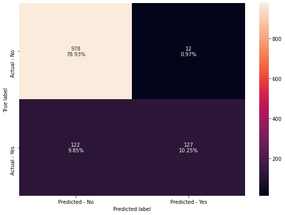

```python
#Creating confusion matrix
make_confusion_matrix(bagging_estimator_tuned,y_test)
```

#### interpretation:

- recall is performing worse, esp on the false negatives

## Boosting Models

### AdaBoost Classifier

```python
#Fitting the model
ab_classifier = AdaBoostClassifier(random_state=1)
ab_classifier.fit(X_train,y_train)

#Calculating different metrics
get_metrics_score(ab_classifier);
```

```
Accuracy on training set :  0.8639667705088265
Accuracy on test set :  0.8539144471347861
Recall on training set :  0.41605839416058393
Recall on test set :  0.42168674698795183
Precision on training set :  0.7574750830564784
Precision on test set :  0.7394366197183099
F1-Score on training set :  0.5371024734982333
F1-Score on test set :  0.5370843989769821
```

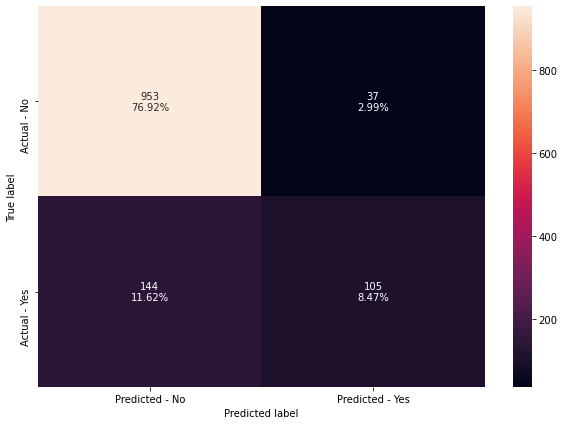

```python
#Creating confusion matrix
make_confusion_matrix(ab_classifier,y_test)
```

#### interpretation:

- recall is very low, as both false positives and false negatives are on the high side
- precision is also low, resulting in a low F1-score

### Hyperparameter Tuning

```python
# Choose the type of classifier.
abc_tuned = AdaBoostClassifier(random_state=1)

# Grid of parameters to choose from
parameters = {
    #Let's try different max_depth for base_estimator
    "base_estimator":[DecisionTreeClassifier(max_depth=1),DecisionTreeClassifier(max_depth=2),
                      DecisionTreeClassifier(max_depth=3)],
    "n_estimators": np.arange(10,110,10),
    "learning_rate":np.arange(0.1,2,0.1)
}

# Type of scoring used to compare parameter  combinations
scorer = metrics.make_scorer(metrics.f1_score)

# Run the grid search
grid_obj = RandomizedSearchCV(abc_tuned, parameters, scoring=scorer,cv=5)
grid_obj = grid_obj.fit(X_train, y_train)

# Set the clf to the best combination of parameters
abc_tuned = grid_obj.best_estimator_

# Fit the best algorithm to the data.
abc_tuned.fit(X_train, y_train)
```

```
AdaBoostClassifier(base_estimator=DecisionTreeClassifier(max_depth=3),
                   learning_rate=0.8, n_estimators=60, random_state=1)
```

```python
#Calculating different metrics
get_metrics_score(abc_tuned);
```

```
Accuracy on training set :  0.9650398061613015
Accuracy on test set :  0.8619854721549637
Recall on training set :  0.8540145985401459
Recall on test set :  0.5180722891566265
Precision on training set :  0.9570552147239264
Precision on test set :  0.7166666666666667
F1-Score on training set :  0.9026036644165862
F1-Score on test set :  0.6013986013986015
```

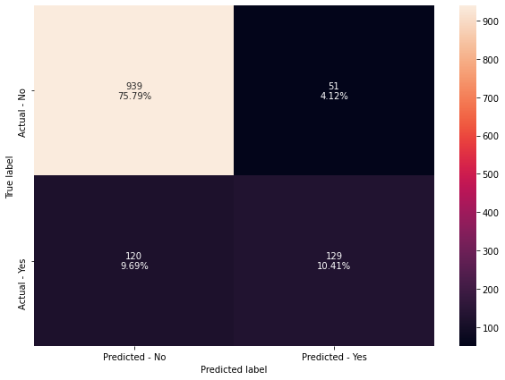

```python
#Creating confusion matrix
make_confusion_matrix(abc_tuned,y_test)
```

### Gradient Boosting Classifier

```python
#Fitting the model
gb_classifier = GradientBoostingClassifier(random_state=1)
gb_classifier.fit(X_train,y_train)
```

```
GradientBoostingClassifier(random_state=1)
```

```python
#Calculating different metrics
get_metrics_score(gb_classifier);
```

```
Accuracy on training set :  0.903772931810315
Accuracy on test set :  0.8595641646489104
Recall on training set :  0.5383211678832117
Recall on test set :  0.39357429718875503
Precision on training set :  0.921875
Precision on test set :  0.8099173553719008
F1-Score on training set :  0.6797235023041476
F1-Score on test set :  0.5297297297297298
```

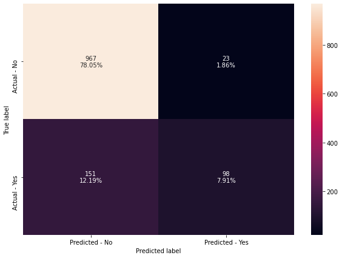

```python
#Creating confusion matrix
make_confusion_matrix(gb_classifier,y_test)
```

#### interpretation:

- recall is extremely bad, with very high false negatives of 12.19%
- the true positive rate is very low too

### Hyperparameter Tuning

```python
# Choose the type of classifier.
gbc_tuned = GradientBoostingClassifier(init=AdaBoostClassifier(random_state=1),random_state=1)

# Grid of parameters to choose from
parameters = {
    "n_estimators": [100,150,200,250],
    "subsample":[0.8,0.9,1],
    "max_features":[0.7,0.8,0.9,1]
}

# Type of scoring used to compare parameter combinations
scorer = metrics.make_scorer(metrics.f1_score)

# Run the grid search
grid_obj = RandomizedSearchCV(gbc_tuned, parameters, scoring=scorer,cv=5)
grid_obj = grid_obj.fit(X_train, y_train)

# Set the clf to the best combination of parameters
gbc_tuned = grid_obj.best_estimator_

# Fit the best algorithm to the data.
gbc_tuned.fit(X_train, y_train)
```

```
GradientBoostingClassifier(init=AdaBoostClassifier(random_state=1),
                           max_features=0.7, n_estimators=250, random_state=1,
                           subsample=0.9)
```

```python
#Calculating different metrics
get_metrics_score(gbc_tuned);
```

```
Accuracy on training set :  0.9390792661820699
Accuracy on test set :  0.8757062146892656
Recall on training set :  0.718978102189781
Recall on test set :  0.4939759036144578
Precision on training set :  0.9471153846153846
Precision on test set :  0.8145695364238411
F1-Score on training set :  0.8174273858921162
F1-Score on test set :  0.615
```

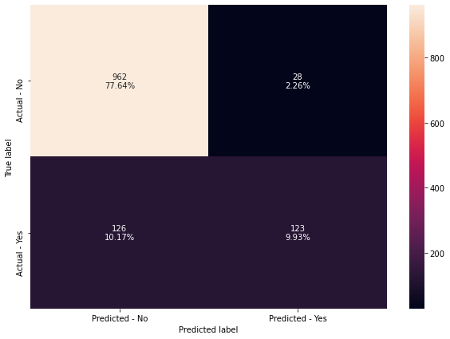

```python
#Creating confusion matrix
make_confusion_matrix(gbc_tuned,y_test)
```

### XGBoost Classifier

```python
#Fitting the model
xgb_classifier = XGBClassifier(random_state=1, eval_metric='logloss')
xgb_classifier.fit(X_train,y_train)

#Calculating different metrics
get_metrics_score(xgb_classifier);
```

```
Accuracy on training set :  1.0
Accuracy on test set :  0.9023405972558515
Recall on training set :  1.0
Recall on test set :  0.5943775100401606
Precision on training set :  1.0
Precision on test set :  0.8809523809523809
F1-Score on training set :  1.0
F1-Score on test set :  0.709832134292566
```

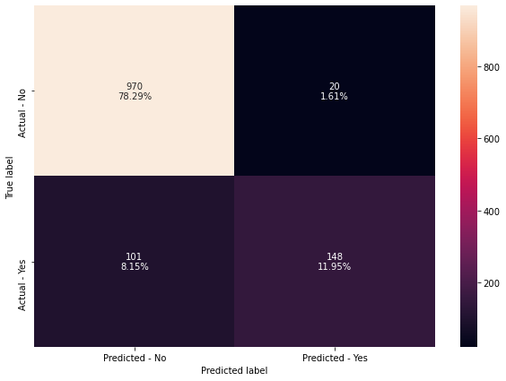

```python
#Creating confusion matrix
make_confusion_matrix(xgb_classifier,y_test)
```

### Hyperparameter Tuning

```python
# Choose the type of classifier.
xgb_tuned = XGBClassifier(random_state=1, eval_metric='logloss')

# Grid of parameters to choose from
parameters = {
    "n_estimators": [10,30,50],
    "scale_pos_weight":[1,2,5],
    "subsample":[0.7,0.9,1],
    "learning_rate":[0.05, 0.1,0.2],
    "colsample_bytree":[0.7,0.9,1],
    "colsample_bylevel":[0.5,0.7,1]
}

# Type of scoring used to compare parameter combinations
scorer = metrics.make_scorer(metrics.f1_score)

# Run the grid search
grid_obj = RandomizedSearchCV(xgb_tuned, parameters,scoring=scorer,cv=5)
grid_obj = grid_obj.fit(X_train, y_train)

# Set the clf to the best combination of parameters
xgb_tuned = grid_obj.best_estimator_

# Fit the best algorithm to the data.
xgb_tuned.fit(X_train, y_train)
```

```
XGBClassifier(base_score=0.5, booster='gbtree', colsample_bylevel=0.5,
              colsample_bynode=1, colsample_bytree=0.9, eval_metric='logloss',
              gamma=0, gpu_id=-1, importance_type='gain',
              interaction_constraints='', learning_rate=0.2, max_delta_step=0,
              max_depth=6, min_child_weight=1, missing=nan,
              monotone_constraints='()', n_estimators=30, n_jobs=4,
              num_parallel_tree=1, random_state=1, reg_alpha=0, reg_lambda=1,
              scale_pos_weight=5, subsample=0.9, tree_method='exact',
              validate_parameters=1, verbosity=None)
```

```python
#Calculating different metrics
get_metrics_score(xgb_tuned);
```

```
Accuracy on training set :  0.9352717203184493
Accuracy on test set :  0.8611783696529459
Recall on training set :  0.9562043795620438
Recall on test set :  0.7590361445783133
Precision on training set :  0.7627365356622998
Precision on test set :  0.627906976744186
F1-Score on training set :  0.848582995951417
F1-Score on test set :  0.6872727272727274
```

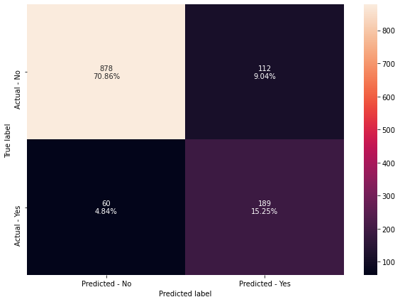

```python
#Creating confusion matrix
make_confusion_matrix(xgb_tuned,y_test)
```

## Stacking Classifier

```python
estimators = {('Random Forest',rf_tuned), ('Gradient Boosting',gbc_tuned), ('Decision Tree',dtree_estimator)}

final_estimator = xgb_tuned

stacking_classifier= StackingClassifier(estimators=estimators,final_estimator=final_estimator)

stacking_classifier.fit(X_train,y_train)
```

```
StackingClassifier(estimators={('Decision Tree',
                                DecisionTreeClassifier(class_weight={0: 0.18,
                                                                     1: 0.72},
                                                       max_depth=5,
                                                       max_leaf_nodes=10,
                                                       min_impurity_decrease=0.001,
                                                       min_samples_leaf=5,
                                                       random_state=1)),
                               ('Gradient Boosting',
                                GradientBoostingClassifier(init=AdaBoostClassifier(random_state=1),
                                                           max_features=0.7,
                                                           n_estimators=250,
                                                           random_state=1,
                                                           subsample=0.9)),
                               ('Ran...
                                                 eval_metric='logloss', gamma=0,
                                                 gpu_id=-1,
                                                 importance_type='gain',
                                                 interaction_constraints='',
                                                 learning_rate=0.2,
                                                 max_delta_step=0, max_depth=6,
                                                 min_child_weight=1,
                                                 missing=nan,
                                                 monotone_constraints='()',
                                                 n_estimators=30, n_jobs=4,
                                                 num_parallel_tree=1,
                                                 random_state=1, reg_alpha=0,
                                                 reg_lambda=1,
                                                 scale_pos_weight=5,
                                                 subsample=0.9,
                                                 tree_method='exact',
                                                 validate_parameters=1,
                                                 verbosity=None))
```

```python
#Calculating different metrics
get_metrics_score(stacking_classifier);
```

```
Accuracy on training set :  0.9477327795084804
Accuracy on test set :  0.8684422921711057
Recall on training set :  0.9799270072992701
Recall on test set :  0.8273092369477911
Precision on training set :  0.793205317577548
Precision on test set :  0.6319018404907976
F1-Score on training set :  0.876734693877551
F1-Score on test set :  0.7165217391304347
```

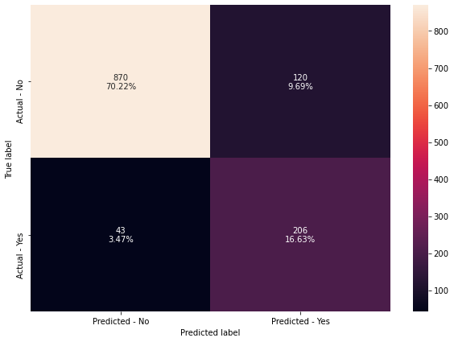

```python
#Creating confusion matrix
make_confusion_matrix(stacking_classifier,y_test)
```

#### interpretation:

- the best recall rate so far, as the false negative rate is only 3.5%
- the false positive rate stands quite high at 10%, but it is less costly than a higher false negative rate
- the accuracy rate is not the best, but at least there is less overfitting

## Comparing all Models

```python
# defining list of models
models = [d_tree, dtree_estimator,rf_estimator, rf_tuned, bagging_classifier,bagging_estimator_tuned,
          ab_classifier, abc_tuned, gb_classifier, gbc_tuned, xgb_classifier,xgb_tuned, stacking_classifier]

# defining empty lists to add train and test results
acc_train = []
acc_test = []
recall_train = []
recall_test = []
precision_train = []
precision_test = []
f1_train = []
f1_test = []

# looping through all the models to get the metrics score - Accuracy, Recall and Precision
for model in models:

    j = get_metrics_score(model,False)
    acc_train.append(j[0])
    acc_test.append(j[1])
    recall_train.append(j[2])
    recall_test.append(j[3])
    precision_train.append(j[4])
    precision_test.append(j[5])
    f1_train.append(j[6])
    f1_test.append(j[7])
```

```python
comparison_frame = pd.DataFrame({'Model':['Decision Tree','Tuned Decision Tree','Random Forest','Tuned Random Forest',
                                          'Bagging Classifier','Bagging Classifier Tuned','AdaBoost Classifier','Tuned AdaBoost Classifier',
                                          'Gradient Boosting Classifier', 'Tuned Gradient Boosting Classifier',
                                          'XGBoost Classifier',  'Tuned XGBoost Classifier', 'Stacking Classifier'],
                                          'Train_Accuracy': acc_train,'Test_Accuracy': acc_test,
                                          'Train_Recall':recall_train,'Test_Recall':recall_test,
                                          'Train_Precision':precision_train,'Test_Precision':precision_test,
                                           'Train_F1-Score':f1_train, 'Test_F1-Score':f1_test})

#Sorting models in decreasing order of test recall
comparison_frame.sort_values(by='Test_F1-Score',ascending=False)
```

|  | Model | Train_Accuracy | Test_Accuracy | Train_Recall | Test_Recall | Train_Precision | Test_Precision | Train_F1-Score | Test_F1-Score |
| --- | --- | --- | --- | --- | --- | --- | --- | --- | --- |
| 12 | Stacking Classifier | 0.947733 | 0.868442 | 0.979927 | 0.827309 | 0.793205 | 0.631902 | 0.876735 | 0.716522 |
| 10 | XGBoost Classifier | 1.000000 | 0.902341 | 1.000000 | 0.594378 | 1.000000 | 0.880952 | 1.000000 | 0.709832 |
| 0 | Decision Tree | 1.000000 | 0.875706 | 1.000000 | 0.710843 | 1.000000 | 0.683398 | 1.000000 | 0.696850 |
| 4 | Bagging Classifier | 0.991693 | 0.899919 | 0.959854 | 0.566265 | 0.996212 | 0.898089 | 0.977695 | 0.694581 |
| 3 | Tuned Random Forest | 0.959848 | 0.882163 | 0.956204 | 0.654618 | 0.850649 | 0.730942 | 0.900344 | 0.690678 |
| 2 | Random Forest | 1.000000 | 0.902341 | 1.000000 | 0.542169 | 1.000000 | 0.950704 | 1.000000 | 0.690537 |
| 11 | Tuned XGBoost Classifier | 0.935272 | 0.861178 | 0.956204 | 0.759036 | 0.762737 | 0.627907 | 0.848583 | 0.687273 |
| 5 | Bagging Classifier Tuned | 0.998615 | 0.891848 | 0.992701 | 0.510040 | 1.000000 | 0.913669 | 0.996337 | 0.654639 |
| 9 | Tuned Gradient Boosting Classifier | 0.939079 | 0.875706 | 0.718978 | 0.493976 | 0.947115 | 0.814570 | 0.817427 | 0.615000 |
| 7 | Tuned AdaBoost Classifier | 0.965040 | 0.861985 | 0.854015 | 0.518072 | 0.957055 | 0.716667 | 0.902604 | 0.601399 |
| 1 | Tuned Decision Tree | 0.823122 | 0.821630 | 0.629562 | 0.590361 | 0.528331 | 0.552632 | 0.574521 | 0.570874 |
| 6 | AdaBoost Classifier | 0.863967 | 0.853914 | 0.416058 | 0.421687 | 0.757475 | 0.739437 | 0.537102 | 0.537084 |
| 8 | Gradient Boosting Classifier | 0.903773 | 0.859564 | 0.538321 | 0.393574 | 0.921875 | 0.809917 | 0.679724 | 0.529730 |